# IPF figures

Jiangyan Yu (jiangyan.yu@uni-bonn.de)

2023-09-25

# 1 general settings

## 1.1 load library

## 1.2 working directory

```r
working.dir = "/home/jyu/rstudio/"

ms_dir = paste0(working.dir,"/IPF_manuscript/manuscriptV3/figures")
ms_date = "20230921"

rm(load_packages)
```

## 1.3 color

### 1.3.1 IPF stages

```r
stage_color = c("Control" = "grey",
                "Early-IPF" = "#076B94",
                "Advanced-IPF" = "#E0B32D"
                )
```

## 1.4 mac_label

```r
mac_label = c("0" = expression(Alveolar*"-"*M*phi1*(0)),
                             "4_0" = "Monocyte(4_0)",
                             "4_1" = expression(RNASE1^"+"*M*phi1*(4*"_"*1)),
                             "4_2" = expression(SPP1^"+"*M*phi1*(4*"_"*2)),
                             "6" = expression(S100A11^"+"*M*phi1*(6)),
                             "7" = expression(MKI67^"+"*M*phi1*(7*","*13*","*20)),
                             "8" = expression(CXCL10^"+"*M*phi1*(8)),
                             "10" = expression(TNFAIP6^"+"*M*phi1*(10)),
                             "11" = expression(NEAT1^"+"*M*phi1*(11)),
                             "13" = expression(MKI67^"+"*M*phi1*(7*","*13*","*20)),
                             "20" = expression(MKI67^"+"*M*phi1*(7*","*13*","*20)))
```

## 1.5 function

### 1.5.1 GSEA

```r
library(biomaRt)
library(org.Hs.eg.db)
library(org.Mm.eg.db)
library(clusterProfiler)
library(DOSE)

gsea_pathway_dir = paste0(working.dir,"/IPF_manuscript/meta_data/gsea_database/")

GSEA_calc_gene <- function(gene_list,
                           DEG_list,
                           comparison = NULL,
                           species = "M", # H for human
                           genes_down = NULL,
                           genes_all = NULL,
                           GeneSets =c("GO","KEGG","DO","Hallmark","cannonicalPathways","Motifs","ImmunoSignatures"),
                           GOntology = "BP", #Alternative "MF" or "CC"
                           pCorrection = "bonferroni", # choose the p-value adjustment method
                           pvalueCutoff = 0.1, # set the unadj. or adj. p-value cutoff (depending on correction method)
                           qvalueCutoff = 0.2 # set the q-value cutoff (FDR corrected)
) {

  # define universe
  universe <- as.character(gene_list)
  # change symbols to ENTREZ IDs (necessary for ClusterProfiler)
  if(species == "M") {
    universe = getLDS(attributes = c("mgi_symbol"),
                      filters = "mgi_symbol",
                      values = universe,
                      mart = useMart("ensembl", dataset = "mmusculus_gene_ensembl",host = "https://dec2021.archive.ensembl.org/"),
                      attributesL = c("hgnc_symbol"),
                      martL = useMart("ensembl", dataset = "hsapiens_gene_ensembl",host = "https://dec2021.archive.ensembl.org/"),
                      uniqueRows=T)[,2]
  }else{}

  universe_Entrez <- bitr(universe,
                          fromType="SYMBOL",
                          toType="ENTREZID",
                          OrgDb="org.Hs.eg.db")$ENTREZID

  human = useMart("ensembl", dataset = "hsapiens_gene_ensembl",host = "https://dec2021.archive.ensembl.org/")
  mouse = useMart("ensembl", dataset = "mmusculus_gene_ensembl",host = "https://dec2021.archive.ensembl.org/")
  # human = useMart("ensembl", dataset = "hsapiens_gene_ensembl",host = "https://www.ensembl.org")
  # mouse = useMart("ensembl", dataset = "mmusculus_gene_ensembl",host = "https://www.ensembl.org")


  genes_up = DEG_list
  # genes_down = DEG_down_list
  # genes_all = DEG_all_list

  if(species == "M") {
    genes_up <- getLDS(attributes = c("mgi_symbol"), filters = "mgi_symbol", values = genes_up, mart = mouse, attributesL = c("hgnc_symbol"), martL = human, uniqueRows=T)[,2]
    # genes_down <- getLDS(attributes = c("mgi_symbol"), filters = "mgi_symbol", values = genes_down, mart = mouse, attributesL = c("hgnc_symbol"), martL = human, uniqueRows=T)[,2]
    # genes_all <- getLDS(attributes = c("mgi_symbol"), filters = "mgi_symbol", values = genes_all, mart = mouse, attributesL = c("hgnc_symbol"), martL = human, uniqueRows=T)[,2]
  }

  cannonicalPathway_genes <- clusterProfiler::read.gmt(paste(gsea_pathway_dir,"c2.all.v7.5.entrez.gmt",sep=""))
  immuno_genes <- clusterProfiler::read.gmt(paste(gsea_pathway_dir,"c7.all.v7.5.entrez.gmt",sep=""))
  hallmark_genes <- clusterProfiler::read.gmt(paste(gsea_pathway_dir,"h.all.v7.5.entrez.gmt",sep=""))
  motifs <- clusterProfiler::read.gmt(paste(gsea_pathway_dir,"c3.all.v7.5.entrez.gmt",sep=""))

  # if(!is.null(group_by)){
  # SetIdents(object = tmp) <- group_by
  # }

  # if(!is.null(genes_down)) {
  #   top_down <- genes_down
  #   entrez_down <- bitr(top_down, fromType = "SYMBOL", toType="ENTREZID", OrgDb=org.Hs.eg.db)$ENTREZID
  # }

  # if(!is.null(genes_all)) {
  #   top_all <- genes_all
  #   entrez_all <- bitr(top_all, fromType = "SYMBOL", toType="ENTREZID", OrgDb=org.Hs.eg.db)$ENTREZID
  # }

  top_up <- genes_up
  entrez_up <- bitr(top_up, fromType = "SYMBOL", toType="ENTREZID", OrgDb=org.Hs.eg.db)$ENTREZID

  OrgDb = org.Hs.eg.db

  results <- list()


  # GO enrichment
  if("GO" %in% GeneSets){
    print("Performing GO enrichment")
    results$GOup <- as.data.frame(enrichGO(gene = entrez_up,
                                           universe = universe_Entrez,
                                           OrgDb = OrgDb,
                                           ont = GOntology,
                                           pAdjustMethod = pCorrection,
                                           pvalueCutoff  = pvalueCutoff,
                                           qvalueCutoff  = qvalueCutoff,
                                           readable      = T))

    if(nrow(results$GOup)>0){results$GOup$Enrichment <- paste("GO enrichment for genes upregulated in comparison ",comparison,sep="")}

    # if(!is.null(genes_down)) {
    #   results$GOdown <- as.data.frame(enrichGO(gene = entrez_down,
    #                                            universe = universe_Entrez,
    #                                            OrgDb = OrgDb,
    #                                            ont = GOntology,
    #                                            pAdjustMethod = pCorrection,
    #                                            pvalueCutoff  = pvalueCutoff,
    #                                            qvalueCutoff  = qvalueCutoff,
    #                                            readable      = T))
    #   if(nrow(results$GOdown)>0){results$GOdown$Enrichment <- paste("GO enrichment for genes downregulated in comparison ",comparison,sep="")}
    # }

  #   if(!is.null(genes_all)) {
  #     results$GOall <- as.data.frame(enrichGO(gene = entrez_all,
  #                                             universe = universe_Entrez,
  #                                             OrgDb = OrgDb,
  #                                             ont = GOntology,
  #                                             pAdjustMethod = pCorrection,
  #                                             pvalueCutoff  = pvalueCutoff,
  #                                             qvalueCutoff  = qvalueCutoff,
  #                                             readable      = T))
  #     if(nrow(results$GOall)>0){results$GOall$Enrichment <- paste("GO enrichment for genes allregulated in comparison ",comparison,sep="")}
  #   }
  }
```

```r
  # KEGG enrichment
  if("KEGG" %in% GeneSets){
    print("Performing KEGG enrichment")

    org = "hsa"

    results$KEGGup <- as.data.frame(enrichKEGG(gene = entrez_up,
                                               organism = org,
                                               universe = universe_Entrez,
                                               pAdjustMethod = pCorrection,
                                               pvalueCutoff  = pvalueCutoff,
                                               qvalueCutoff = qvalueCutoff))
    if(nrow(results$KEGGup)>0){results$KEGGup$Enrichment <- paste("KEGG enrichment for genes upregulated in comparison ",comparison,sep="")}

    # if(!is.null(genes_down)) {
    #   results$KEGGdown <- as.data.frame(enrichKEGG(gene = entrez_down,
    #                                                organism = org,
    #                                                universe = universe_Entrez,
    #                                                pAdjustMethod = pCorrection,
    #                                                pvalueCutoff  = pvalueCutoff,
    #                                                qvalueCutoff = qvalueCutoff))
    #   if(nrow(results$KEGGdown)>0){results$KEGGdown$Enrichment <- paste("KEGG enrichment for genes downregulated in comparison ",comparison,sep="")}
    # }
  }

  # DO enrichment
  if("DO" %in% GeneSets){
    print("Performing Disease Ontology enrichment")

    results$DOup <- as.data.frame(enrichDO(gene = entrez_up,
                                           universe = universe_Entrez,
                                           pAdjustMethod = pCorrection,
                                           pvalueCutoff  = pvalueCutoff,
                                           qvalueCutoff = qvalueCutoff,
                                           minGSSize     = 5,
                                           maxGSSize     = 500,
                                           readable=TRUE))
    if(nrow(results$DOup)>0){results$DOup$Enrichment <- paste("DO enrichment for genes upregulated in comparison ",comparison,sep="")}

    # if(!is.null(genes_down)) {
    #   results$DOdown <- as.data.frame(enrichDO(gene = entrez_down,
    #                                            universe = universe_Entrez,
    #                                            pAdjustMethod = pCorrection,
    #                                            pvalueCutoff  = pvalueCutoff,
    #                                            qvalueCutoff = qvalueCutoff,
    #                                            minGSSize     = 5,
    #                                            maxGSSize     = 500,
    #                                            readable=TRUE))
    #   if(nrow(results$DOdown)>0){results$DOdown$Enrichment <- paste("DO enrichment for genes downregulated in comparison ",comparison,sep="")}
    # }
  }

  # Hallmark enrichment
  if("Hallmark" %in% GeneSets){
    print("Performing Hallmark enrichment")

    results$HALLMARKup <- as.data.frame(enricher(entrez_up,
                                                 TERM2GENE=hallmark_genes,
                                                 universe = universe_Entrez,
                                                 pAdjustMethod = pCorrection,
                                                 pvalueCutoff  = pvalueCutoff,
                                                 qvalueCutoff = qvalueCutoff))
    if(nrow(results$HALLMARKup)>0){results$HALLMARKup$Enrichment <- paste("HALLMARK enrichment for genes upregulated in comparison ",comparison,sep="")}

    # if(!is.null(genes_down)) {
    #   results$HALLMARKdown <- as.data.frame(enricher(entrez_down,
    #                                                  TERM2GENE=hallmark_genes,
    #                                                  universe = universe_Entrez,
    #                                                  pAdjustMethod = pCorrection,
    #                                                  pvalueCutoff  = pvalueCutoff,
    #                                                  qvalueCutoff = qvalueCutoff))
    #   if(nrow(results$HALLMARKdown)>0){results$HALLMARKdown$Enrichment <- paste("HALLMARK enrichment for genes downregulated in comparison ",comparison,sep="")}
    # }
  }

  # Cannonical Pathway enrichment
  if("cannonicalPathways" %in% GeneSets){
    print("Performing Cannonical Pathway (C2) enrichment")

    results$cannonicalPathwaysup <- as.data.frame(enricher(entrez_up,
                                                           TERM2GENE=cannonicalPathway_genes,
                                                           universe = universe_Entrez,
                                                           pAdjustMethod = pCorrection,
                                                           pvalueCutoff  = pvalueCutoff,
                                                           qvalueCutoff = qvalueCutoff))
    if(nrow(results$cannonicalPathwaysup)>0){results$cannonicalPathwaysup$Enrichment <- paste("Cannonical pathway enrichment for genes upregulated in comparison ",comparison,sep="")}

    # if(!is.null(genes_down)) {
    #   results$cannonicalPathwaysdown <- as.data.frame(enricher(entrez_down,
    #                                                            TERM2GENE=cannonicalPathway_genes,
    #                                                            universe = universe_Entrez,
    #                                                            pAdjustMethod = pCorrection,
    #                                                            pvalueCutoff  = pvalueCutoff,
    #                                                            qvalueCutoff = qvalueCutoff))
    #   if(nrow(results$cannonicalPathwaysdown)>0){results$cannonicalPathwaysdown$Enrichment <- paste("Cannonical pathway enrichment for genes downregulated in comparison ",comparison,sep="")}
    # }
  }

  # Motif enrichment
  if("Motifs" %in% GeneSets){
    print("Performing Motif enrichment")
```

```r
    results$Motifup <- as.data.frame(enricher(entrez_up,
                                              TERM2GENE=motifs,
                                              universe = universe_Entrez,
                                              pAdjustMethod = pCorrection,
                                              pvalueCutoff  = pvalueCutoff,
                                              qvalueCutoff = qvalueCutoff))
    if(nrow(results$Motifup)>0){results$Motifup$Enrichment <- paste("TF binding motif enrichment for genes upregulated in comparison ",comparison,sep="")}

    # if(!is.null(genes_down)) {
    #   results$Motifdown <- as.data.frame(enricher(entrez_down,
    #                                               TERM2GENE=motifs,
    #                                               universe = universe_Entrez,
    #                                               pAdjustMethod = pCorrection,
    #                                               pvalueCutoff  = pvalueCutoff,
    #                                               qvalueCutoff = qvalueCutoff))
    #   if(nrow(results$Motifdown)>0){results$Motifdown$Enrichment <- paste("TF binding motif enrichment for genes downregulated in comparison",comparison,sep="")}
    # }
  }

  # Immunosignatures enrichment
  if("ImmunoSignatures" %in% GeneSets){
    print("Performing immunesignature enrichment")

    results$ImmSigup <- as.data.frame(enricher(entrez_up,
                                               TERM2GENE=immuno_genes,
                                               universe = universe_Entrez,
                                               pAdjustMethod = pCorrection,
                                               pvalueCutoff  = pvalueCutoff,
                                               qvalueCutoff = qvalueCutoff))
    if(nrow(results$ImmSigup)>0){results$ImmSigup$Enrichment <- paste("Immunosignature enrichment for genes upregulated in comparison ",comparison,sep="")}

    # if(!is.null(genes_down)) {
    #   results$ImmSigdown <- as.data.frame(enricher(entrez_down,
    #                                                TERM2GENE=immuno_genes,
    #                                                universe = universe_Entrez,
    #                                                pAdjustMethod = pCorrection,
    #                                                pvalueCutoff  = pvalueCutoff,
    #                                                qvalueCutoff = qvalueCutoff))
    #   if(nrow(results$ImmSigdown)>0){results$ImmSigdown$Enrichment <- paste("Immunosignature enrichment for genes downregulated in comparison ",comparison,sep="")}
    # }
  }
  return(results)
}
```

### 1.5.2 gsea dotplot

```r
dotplotGSEA <- function(x,
                        show=25,
                        font.size=10,
                        title.size=10,
                        title.width=100,
                        order="count"){
  if(nrow(x)<1){
    print("No enrichment found.")
  }else{
    x <- if(nrow(x)>show){x[c(1:show),]}else{x}
    if(order=="padj"){
      x <- x[order(x$Count,decreasing=FALSE),]
      x <- x[order(x$p.adjust,decreasing=TRUE),]
      x$Description <- ifelse(nchar(x$Description)<500,
                              paste(substr(x$Description, 1, 500),"[...]",sep=""),
                              x$Description)
      x$Description <- factor(x$Description, levels = unique(x$Description))
    }
    if(order=="count"){
      x <- x[order(x$Count,decreasing=FALSE),]
      x$Description <- ifelse(nchar(x$Description)>500,
                              paste(substr(x$Description, 1, 500),"[...]",sep=""),
                              x$Description)
      x$Description <- factor(x$Description, levels = unique(x$Description))
      x$GeneRatio <- factor(x$GeneRatio, levels = unique(x$GeneRatio))
    }

    ggplot(x, aes(x = GeneRatio, y = Description, color = p.adjust)) +
      geom_point(aes(size = Count)) +
      scale_colour_gradientn(colours=c('red',
                                       'orange',
                                       'darkblue',
                                       'darkblue'),
                             limits=c(0,1),
                             values   = c(0,0.05,0.2,0.5,1),
                             breaks   = c(0.05,0.2,1),
                             labels = format(c(0.05,0.2,1))) +
      ylab(NULL) +
      ggtitle(paste(strwrap(unique(x$Enrichment), width=title.width), collapse = "\n"))+
      theme_classic() +
      scale_y_discrete(position = "right") +
      theme(text = element_text(size=font.size),
            plot.title = element_text(size=title.size))
  }
}
```

# 2 load seurat object

```r
ipf_seu_mac = readRDS(file=paste0(working.dir,"/IPF_manuscript/data/ILD_combined_sct_rpca20230720_mac_momac.rds"))


## combine mik67+ clusters

ipf_seu_mac$subcluster1 = ifelse(ipf_seu_mac$subcluster %in% c(13,20),"7",as.character(ipf_seu_mac$subcluster))
ipf_seu_mac$subcluster1 = factor(ipf_seu_mac$subcluster1,levels = c(0,"4_0","4_1","4_2",6,8,10,11,7))


Idents(ipf_seu_mac) = "subcluster1"

##use same colors for cluster 7, 13, 20
mac_color = c("0" = "#344e41",
                             "4_0" = "#FF1493",
                         "4_1" = "#48cae4",
                         "4_2" = "#ffafcc",
                             "6" = "#BDE4C8",
                             "8" = "#73BCEB",
                             "10" = "#00b4d8",
                             "11" = "#467599",
                             "7" = "#6a994e")


mac_label = c("0" = expression(Alveolar*"-"*M*phi1*(0)),
                             "4_0" = "Monocyte(4_0)",
                             "4_1" = expression(RNASE1^"+"*M*phi1*(4*"_"*1)),
                             "4_2" = expression(SPP1^"+"*M*phi1*(4*"_"*2)),
                             "6" = expression(S100A11^"+"*M*phi1*(6)),
                             "8" = expression(CXCL10^"+"*M*phi1*(8)),
                             "10" = expression(TNFAIP6^"+"*M*phi1*(10)),
                             "11" = expression(NEAT1^"+"*M*phi1*(11)),
                             "7" = expression(MKI67^"+"*M*phi1*(7*","*13*","*20)))
```

## 2.1 Projecting to MoMac

```r
# momac = readRDS(paste0(working.dir,"/IPF_manuscript/data/2021_MoMac_VERSE.RDS"))
# momac_meta = momac@meta.data
# lung_momac = subset(momac, subset=Tissue =="Lung")
#
# rm(momac)
#
# gc()
#
# # Double check which assay your datasets are in, I think RNA assay is probably best
# DefaultAssay(lung_momac) <- "integrated"
# DefaultAssay(ipf_seu_mac) <- "integrated"
# # find transfer anchors
# Transfer.anchors <- FindTransferAnchors(reference = lung_momac, query = ipf_seu_mac,
#                                         dims = 1:30)
# # generate prediction scores
# predictions <- TransferData(anchorset = Transfer.anchors, refdata = lung_momac$Clusters,
#                             dims = 1:30)
# # add prediction scores to metadata of your query object
# ipf_seu_mac <- AddMetaData(ipf_seu_mac, metadata = predictions)
#
# saveRDS(ipf_seu_mac, file=paste0(working.dir,"/IPF_manuscript/data/ILD_combined_sct_rpca20230720_mac_momac.rds"))
```

# 3 figure 3B

```r
library(ComplexHeatmap)
tmp_prediction = colnames(ipf_seu_mac@meta.data)[colnames(ipf_seu_mac@meta.data) %like% "%prediction.score%"]

tmp_data = cbind(ipf_seu_mac@meta.data$subcluster1,ipf_seu_mac@meta.data[,c(tmp_prediction)])


colnames(tmp_data)[1] = "subcluster1"
tmp_data = tmp_data%>%
  group_by(subcluster1)%>%
  summarise(across(tmp_prediction, mean)) %>%
  as.data.frame()
```

```
## Note: Using an external vector in selections is ambiguous.
## i Use `all_of(tmp_prediction)` instead of `tmp_prediction` to silence this message.
## i See <https://tidyselect.r-lib.org/reference/faq-external-vector.html>.
```

```r
rownames(tmp_data) = tmp_data$subcluster
tmp_data = tmp_data[,-1]
colnames(tmp_data) = str_replace(colnames(tmp_data),"prediction.score.","")

## organize momac clusters based on origin
tmp_data = tmp_data[c("4_0","4_2","4_1",6,8,0,10,11,7),c("CD16..Monocytes..1","CD16..Monocytes..5","CD16..Monocytes..8","IL1B.Monocytes..15","CD16..Monocytes..12","ISG.Monocytes..4","TREM2.Macrophage..3","C1Q.Macrophage..16","IL4I1.Macrophage..6","Macrophage..7","HES1.Macrophage..2","FTL.Macrophage..17","Proliferating.cells..10")]

colnames(tmp_data) = c("CD16+Monocytes(#1)","CD16+Monocytes(#5)","CD16-Monocytes(#8)","IL1B+Monocytes(#15)","CD16-Monocytes(#12)","ISG+Monocytes(#4)","TREM2+Macrophage(#3)","C1Q+Macrophage(#16)","IL4I1+Macrophage(#6)","moDC(#7)","HES1+Macrophage(#2)","FTL+Macrophage(#17)","ProliferatingCells(#10)")


pdf(file = paste0(ms_dir,"/fig3b.MoMac_prediction_score_",ms_date,".pdf"),paper = "a4",width = 3.5,height = 4.5)

col_fun = circlize::colorRamp2(c(0,0.25,0.5,0.75, 1), c("lightblue","white","pink","red","#9d0208"))

col_ha = ComplexHeatmap::HeatmapAnnotation(Type=c("ncMo","ncMo","Mo","Mo","Mo","Mo","MoMac","MoMac","MoMac","MoMac","Mac","Mac","Prolif"),
                                           col = list(Type = c("ncMo"="grey","Mo"="pink","MoMac"="red","Mac"="lightblue","Prolif"="green")),
                                           annotation_name_gp = gpar(fontsize=8),
                                           gp = gpar(fontsize=8),
                                           annotation_name_side = "left",
                                           annotation_legend_param = list(Type=list(title="Type",at = c("ncMo","Mo","MoMac","Mac","Prolif"),labels=c("Non-classical monocyte","Monocyte","Monocyte-derived macrophage","Tissue-resident macrophage","Prolifrating cells"),title_gp = gpar(fontsize=8),labels_gp = gpar(fontsize=8)))

)

ht1 = ComplexHeatmap::Heatmap(tmp_data,
                        name = "Prediction score",
                        col = col_fun,
                        cluster_rows = FALSE,
                        cluster_columns = FALSE,
                        # row_names_side = "right",
                        show_row_names = FALSE,
                        column_names_side = "top",
                        column_title_gp = gpar(fontsize=8),
                        column_names_gp = gpar(fontsize=8),
                        top_annotation = col_ha,

                        row_title_gp = gpar(fontsize=8),
                        # row_names_gp = gpar(fontsize=8),
                        row_title = "Clusters from present study",
                        row_title_side = "left",
                        column_title = "Clusters from MoMac-VERSE (Mulder et al.)",
                        heatmap_legend_param = list(color_bar = "continuous", legend_direction = "horizontal",
                                                    title_gp = gpar(fontsize=8),labels_gp = gpar(fontsize=8),
                                                    legend_width = unit(2, "cm")),
                        left_annotation = ComplexHeatmap::rowAnnotation(labels = ComplexHeatmap::anno_text(c(
    expression(Monocyte*(4*"_"*0)),
    expression(SPP1^"+"*M*phi1*(4*"_"*2)),
    expression(RNASE1^"+"*M*phi1*(4*"_"*1)),
    expression(S100A11^"+"*M*phi1*(6)),
    expression(CXCL10^"+"*M*phi1*(8)),
    expression(Alveolar*"-"*M*phi1*(0)),
    expression(TNFAIP6^"+"*M*phi1*(10)),
    expression(NEAT1^"+"*M*phi1*(11)),
    expression(MKI67^"+"*M*phi1*(7*","*13*","*20))
    ),gp = gpar(fontsize=8),just = "right",location = 1
    )
  )
                        )
ComplexHeatmap::draw(ht1,
                     merge_legend=TRUE,
                        legend_grouping = "original",
                        heatmap_legend_side = "bottom"
                     )

dev.off()
```

[figure not shown]

```r
ComplexHeatmap::draw(ht1,
                     merge_legend=TRUE,
                        legend_grouping = "original",
                        heatmap_legend_side = "bottom"
                     )
```

```r
rm(tmp_prediction,tmp_data,col_fun,col_ha,ht1)
```

# 4 figure 3C

## 4.1 select momac clusters

```r
# # BiocManager::install("destiny")
# library(destiny)
#
# ## per momac cluster select the same number of cells
#
# # # num_cells = min(table(ipf_seu_mac$subcluster))
# num_cells = 500
# traj_seurat = subset(ipf_seu_mac,ident=c("4_0","4_1","4_2",6,8))
# traj_cells = traj_seurat@meta.data
# traj_cells$cellid = rownames(traj_cells)
# traj_cells = traj_cells %>% group_by(subcluster) %>% slice_sample(n=num_cells)
# traj_seurat = traj_seurat[,traj_cells$cellid]
#
# rm(num_cells,traj_cells)
```

## 4.2 destiny

```r
# tmp_cmt = traj_seurat@reductions$pca@cell.embeddings %>% as.data.frame()
#
# sigmas <- find_sigmas(tmp_cmt, verbose = FALSE)  # find optimal sigma
# dm <- DiffusionMap(tmp_cmt, sigma = optimal_sigma(sigmas),k = 5)
# write.csv(eigenvectors(dm),paste0(working.dir,"/IPF_manuscript/meta_data/momac_clusters_diffusionmap_20230728.csv"))
# rm(tmp_cmt,traj_seurat,sigmas,dm)
```

## 4.3 plot

```r
dm= read.csv(paste0(working.dir,"/IPF_manuscript/meta_data/momac_clusters_diffusionmap_20230728.csv"))
# Plot eigenvalues of diffusion distance matrix. How many diffusion components would you use?
# This is analagous to the PC elbow plot (scree plot) that we previously used to assess how
# many PCs to use in downstream applications like clustering.
# plot(dm, ylim = 0:1, pch = 20, xlab = 'Diffusion component (DC)', ylab = 'Eigenvalue')



# Plot diffusion component 1 vs diffusion component 2 (DC1 vs DC2).
tmp <- data.frame(DC1 = dm[, "DC1"],
                  DC2 = dm[, "DC2"],
                  DC3 = dm[, "DC3"],
                  DC4 = dm[, "DC4"],
                  subcluster = as.character(ipf_seu_mac@meta.data[dm$X,"subcluster"]),
                  IPFgroup = ipf_seu_mac@meta.data[dm$X,"IPFgroup"],
                  cellid = ipf_seu_mac@meta.data[dm$X,"cellID"] )
tmp$subcluster = factor(tmp$subcluster,levels = c("4_0","4_1","4_2","6","8"))
rownames(tmp) = tmp$cellid
plot_color = c("4_0" = "#FF1493",
                         "4_1" = "#48cae4",
                         "4_2" = "#ffafcc",
                             "6" = "#BDE4C8",
                             "8" = "#73BCEB")


plot_label = c("4_0" = "Monocyte(4_0)",
                             "4_1" = expression(RNASE1^"+"*M*phi1*(4*"_"*1)),
                             "4_2" = expression(SPP1^"+"*M*phi1*(4*"_"*2)),
                             "6" = expression(S100A11^"+"*M*phi1*(6)),
                             "8" = expression(CXCL10^"+"*M*phi1*(8)))

pdf(file = paste0(ms_dir,"/fig3c.MoMac_diffusion_map_",ms_date,".pdf"),paper = "a4",width = 2.5,height = 2.5)

p = ggplot(tmp, aes(x = DC2, y = DC4,color=subcluster)) +
    geom_point(size=1) +
    xlab("Diffusion component 2") +
    ylab("Diffusion component 4") +
  annotate("text",x=0.03,y=-0.05,label=plot_label["4_0"],color=plot_color["4_0"],size=2.5)+
  annotate("text",x=0.07,y=-0.025,label=plot_label["8"],color=plot_color["8"],size=2.5)+
  annotate("text",x=0.095,y=0.02,label=plot_label["4_1"],color=plot_color["4_1"],size=2.5)+
  annotate("text",x=0.03,y=0.05,label=plot_label["6"],color=plot_color["6"],size=2.5)+
  annotate("text",x=0.01,y=0.07,label=plot_label["4_2"],color=plot_color["4_2"],size=2.5)+
  theme_classic()+
    theme(axis.line = element_blank(),
        axis.text = element_blank(),
        axis.ticks = element_blank(),
        axis.title = element_text(size=8),
        plot.title = element_text(hjust=0.5,face = "plain",size = 8),
        panel.border = element_rect(color = "black",size=0.8,fill = NA),
        legend.position = "none"
        # legend.text = element_text(size = 8,colour = "black"),
        # legend.text.align = 0,
        # legend.key.size = unit(0.5,"cm"),
        # legend.title = element_text(size = 8)
          # legend.text = element_text(size = 20),
          # legend.key.size  = unit(1.3,"cm")
        )+
  scale_color_manual(name = "Cluster",
                     labels = plot_label,
                     values = plot_color)

plot(p)
dev.off()
```

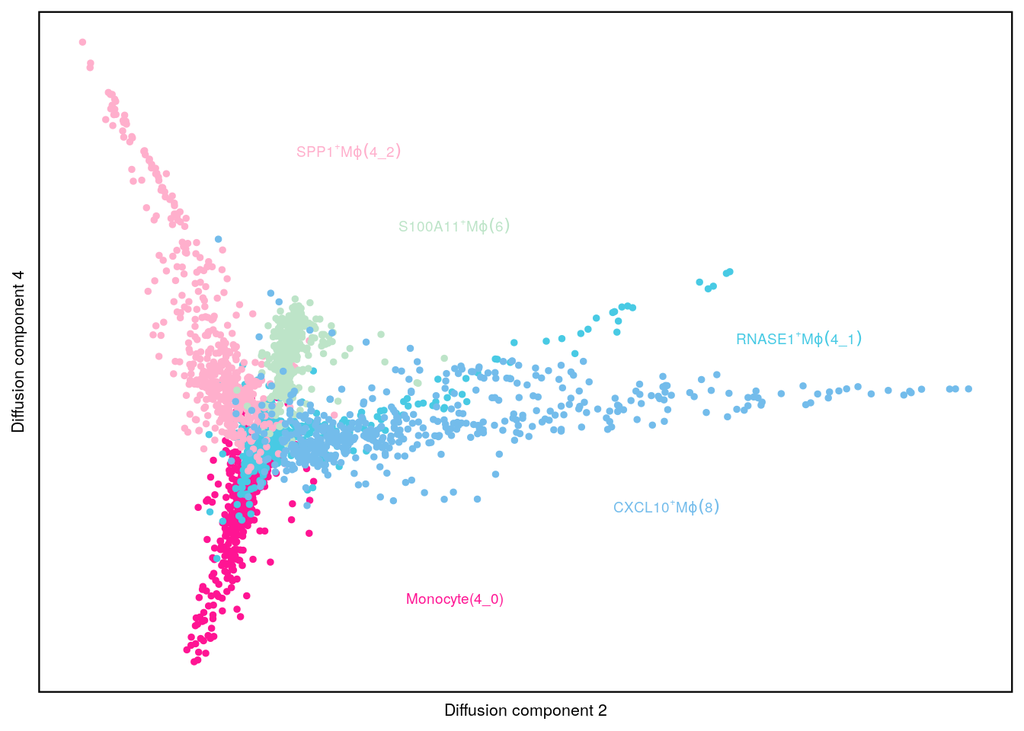

```r
p
```

```r
rm(dm,tmp,plot_color,plot_label,p)
```

# 5 figure 3D temperary genes

```r
# install.packages("gam")
library(gam)
```

```r
dm= read.csv(paste0(working.dir,"/IPF_manuscript/meta_data/momac_clusters_diffusionmap_20230728.csv"))
# Plot eigenvalues of diffusion distance matrix. How many diffusion components would you use?
# This is analagous to the PC elbow plot (scree plot) that we previously used to assess how
# many PCs to use in downstream applications like clustering.
# plot(dm, ylim = 0:1, pch = 20, xlab = 'Diffusion component (DC)', ylab = 'Eigenvalue')



# Plot diffusion component 1 vs diffusion component 2 (DC1 vs DC2).
tmp <- data.frame(DC1 = dm[, "DC1"],
                  DC2 = dm[, "DC2"],
                  DC3 = dm[, "DC3"],
                  DC4 = dm[, "DC4"],
                  subcluster = as.character(ipf_seu_mac@meta.data[dm$X,"subcluster"]),
                  IPFgroup = ipf_seu_mac@meta.data[dm$X,"IPFgroup"],
                  cellid = ipf_seu_mac@meta.data[dm$X,"cellID"] )
tmp$subcluster = factor(tmp$subcluster,levels = c("4_0","4_1","4_2","6","8"))
rownames(tmp) = tmp$cellid

dm1 = subset(tmp,subcluster == "4_0"| subcluster == "4_2")

ipf_seu_mac_dm = ipf_seu_mac[,rownames(dm1)]
ipf_seu_mac_dm$pseudo = dm1$DC4

# Fit GAM for each gene using pseudotime as independent variable.
t <- ipf_seu_mac_dm$pseudo
gam.pval <- apply(ipf_seu_mac_dm@assays$integrated@data, 1, function(z){
  d <- data.frame(z=z, t=t)
  tmp <- gam(z ~ lo(t), data=d)
  p <- summary(tmp)[4][[1]][1,5]
  p

})

gam.coe <- apply(ipf_seu_mac_dm@assays$integrated@data, 1, function(z){
  d <- data.frame(z=z, t=t)
  tmp <- gam(z ~ lo(t), data=d)
  # p <- summary(tmp)[1][[2]][2]
  # p = tmp[[1]][2][[1]][2]
  tmp

})

gam.coe1 = sapply(gam.coe,function(z){
  p = z[2][1][[1]][2]
  p
  })

gam.resu = cbind(gam.pval,gam.coe1)
colnames(gam.resu) = c("pval","coe")

gam.resu1 = subset(as.data.frame(gam.resu),pval < 0.001)
downgenes = gam.resu1[order(gam.resu1$coe),]
topgenes = gam.resu1[order(gam.resu1$coe,decreasing = TRUE),]
```

## 5.1 order pseudotime

```r
### order pseudotime

t1 = as.data.frame(t)
t1$cellid = rownames(t1)
t1 = t1[order(t1$t,decreasing = FALSE),]

dm1_plot = ipf_seu_mac_dm@assays$integrated@scale.data[c(rownames(downgenes)[1:15],rownames(topgenes)[1:15]),t1$cellid]

dm1_plot1 = ipf_seu_mac_dm@meta.data[t1$cellid,"subcluster1"]

# library(ComplexHeatmap)

pdf(file = paste0(ms_dir,"/fig3D.MoMac_pseudotime_deg_",ms_date,".pdf"),paper = "a4",width = 2.5,height = 3.5)

col_fun = circlize::colorRamp2(c(-3,-2.5,0,2.5, 3), c("blue","lightblue","white","pink","#9d0208"))
p  = ComplexHeatmap::Heatmap(as.matrix(dm1_plot),
                             name = "Expression",
                             col = col_fun,
                             border = TRUE,
                        top_annotation = HeatmapAnnotation(
                                                           Pseudotime = t1$t,
                                                           annotation_name_gp = gpar(fontsize=8),
                                                           show_legend = FALSE,
                                                           col = list(Pseudotime = circlize::colorRamp2(c(min(t1$t),mean(t1$t),max(t1$t)),c("blue","pink","yellow"))),
                                                           annotation_legend_param = list(title_gp = gpar(fontsize=8),labels_gp = gpar(fontsize=8))
                                                           ),
                        # column_split = 2,
                        # column_title = c("Monocyte","SPP1"),
                        row_names_gp = gpar(fontsize=8),

                        cluster_rows = FALSE,
                        cluster_columns = FALSE,
                        show_column_names = FALSE,
                        heatmap_legend_param = list(color_bar = "continuous", legend_direction = "vertical",
                                                    title_gp = gpar(fontsize=8),labels_gp = gpar(fontsize=8),
                                                    legend_width = unit(2, "cm"))
                        )
draw(p,heatmap_legend_side = "right",merge_legend=TRUE)

dev.off()
```

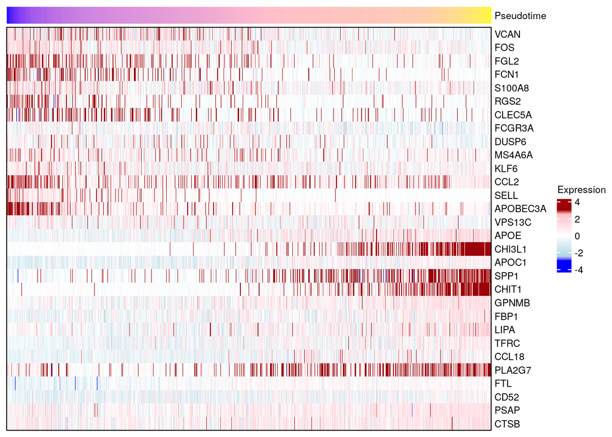

```r
draw(p,heatmap_legend_side = "right",merge_legend=TRUE)
```

```r
rm(dm,tmp,dm1,ipf_seu_mac_dm,t,gam.pval,gam.coe,gam.coe1,gam.resu,gam.resu1,downgenes, topgenes, t1, dm1_plot,dm1_plot1,col_fun,p)
```

# 6 figure 3F

```r
library(ComplexHeatmap)

momac_stim = read.csv(paste0(working.dir,"/IPF_manuscript/manuscriptV3/meta_data/Xue_momac_stimulation_score.csv"))
tmp_prediction = colnames(momac_stim)[colnames(momac_stim) %like% "%momac%"]
tmp_data = cbind(momac_stim$subcluster1,momac_stim[,tmp_prediction])


colnames(tmp_data)[1] = "subcluster"
tmp_data = tmp_data%>%
  group_by(subcluster)%>%
  summarise(across(tmp_prediction, mean)) %>%
  as.data.frame()

rownames(tmp_data) = tmp_data$subcluster
tmp_data = tmp_data[,-1]
colnames(tmp_data) = str_replace(colnames(tmp_data),"momac","")
colnames(tmp_data) = substr(colnames(tmp_data),1,nchar(colnames(tmp_data))-1)

## organize momac clusters based on origin
tmp_data = tmp_data[c(0,"4_0","4_1","4_2",6,8,10,11,7),]

pdf(file = paste0(ms_dir,"/fig3f_Xu_Momac_stimulation",ms_date,".pdf"),paper = "a4",width = 5,height =3)

col_fun = circlize::colorRamp2(c(-3, 0, 3), c("#a8dadc","white","#9d0208"))

ht1 = ComplexHeatmap::Heatmap(scale(tmp_data),
                        name = "Scaled prediction score",
                        col = col_fun,
                        cluster_rows = FALSE,
                        cluster_columns = TRUE,
                        # row_names_side = "left",
                        show_row_names = FALSE,
                        show_heatmap_legend = FALSE,
                        column_names_side = "bottom",
                        column_names_gp = gpar(fontsize=8),
                        column_title_gp = gpar(fontsize=8),
                        row_names_gp = gpar(fontsize=8),
                        row_title_gp = gpar(fontsize=8),
                        row_title = "",
                        column_title = "Stimulated MoMacs (Xue et al.)",
                        heatmap_legend_param = list(color_bar = "continuous", legend_direction = "horizontal",
                                                    title_gp = gpar(fontsize=8),labels_gp = gpar(fontsize=8),
                                                    legend_width = unit(2, "cm"))
                        )+
  ComplexHeatmap::rowAnnotation(labels = ComplexHeatmap::anno_text(c(
    expression(Alveolar*"-"*M*phi1*(0)),
    expression(Monocyte*(4*"_"*0)),
    expression(RNASE1^"+"*M*phi1*(4*"_"*1)),
    expression(SPP1^"+"*M*phi1*(4*"_"*2)),
    expression(S100A11^"+"*M*phi1*(6)),
    expression(CXCL10^"+"*M*phi1*(8)),
    expression(TNFAIP6^"+"*M*phi1*(10)),
    expression(NEAT1^"+"*M*phi1*(11)),
    expression(MKI67^"+"*M*phi1*(7*","*13*","*20))
    ),gp = gpar(fontsize=8)
    # just = "right",location = 1
    )
    )

lgd = Legend(title="Scaled score",col_fun = col_fun,direction = "horizontal",grid_width = unit(2,"cm"),title_gp = gpar(fontsize=8),labels_gp = gpar(fontsize=8))

ComplexHeatmap::draw(ht1)
ComplexHeatmap::draw(lgd,x=unit(0.9,"npc"),y=unit(0.2,"npc"))

dev.off()
```

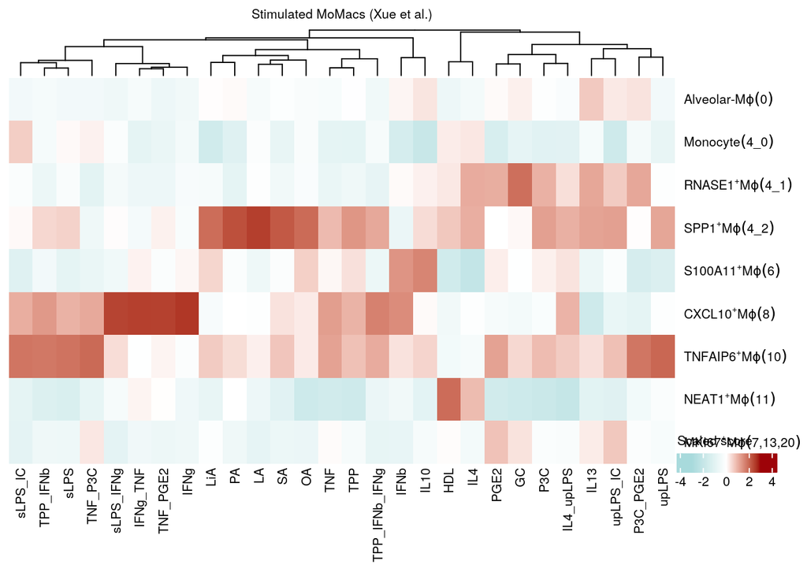

```r
ComplexHeatmap::draw(ht1)
ComplexHeatmap::draw(lgd,x=unit(0.9,"npc"),y=unit(0.2,"npc"))
```

```r
rm(tmp_prediction,tmp_data,col_fun,ht1,lgd,momac_stim)
```

# 7 figure 3G

## 7.1 GSEA

take avg_log2FC > 0.25

```r
# run1to4_ck_ipf_n_copd_ck_deg = read.csv(file = paste0(working.dir,"/IPF_manuscript/meta_data/ILD_combined_sct_rpca20230720_mac_subcluster_deg.csv"))
#
# gsea_data = data.frame()
# for(i in c("7","4_0","6","13","20","4_1","8","10","11","4_2")){
# # for(i in c("4_2")){
#   tmp_genes = subset(run1to4_ck_ipf_n_copd_ck_deg,cluster==i & avg_log2FC > 0.25)
#
#   tmp_gsea = GSEA_calc_gene(gene_list = rownames(ipf_seu_mac),
#                           DEG_list = tmp_genes$gene,
#                            comparison = NULL,
#                            species = "H", # H for human
#                            genes_down = NULL,
#                            genes_all = NULL,
#                            # GeneSets =c("GO","KEGG","DO","Hallmark","cannonicalPathways","Motifs","ImmunoSignatures"),
#                           GeneSets =c("GO"),
#                            GOntology = "BP", #Alternative "MF" or "CC"
#                            pCorrection = "bonferroni", # choose the p-value adjustment method
#                            pvalueCutoff = 1, # set the unadj. or adj. p-value cutoff (depending on correction method)
#                            qvalueCutoff = 1 # set the q-value cutoff (FDR corrected))
#   )
#
#   tmp_gsea1 = tmp_gsea$GOup
#   tmp_gsea1$cluster = i
#
#   if(i == 7 ){
#     gsea_data = tmp_gsea1
#   }else(
#     gsea_data = rbind(gsea_data,tmp_gsea1)
#   )
#
# }
#
# rm(run1to4_ck_ipf_n_copd_ck_deg,i,tmp_genes,tmp_gsea,tmp_gsea1)
#
# write.csv(gsea_data,file = paste0(working.dir,"/IPF_manuscript/meta_data/GSEA_allmac.csv"))
```

## 7.2 plot network

```r
run1to4_ck_ipf_n_copd_ck_deg = read.csv(file = paste0(working.dir,"/IPF_manuscript/manuscriptV3/meta_data/ILD_combined_sct_rpca20230720_mac_subcluster_deg.csv"))
tmp_genes = subset(run1to4_ck_ipf_n_copd_ck_deg,cluster=="4_2" & avg_log2FC > 0.25)

universe_Entrez <- bitr(rownames(ipf_seu_mac@assays$RNA@counts),
                          fromType="SYMBOL",
                          toType="ENTREZID",
                          OrgDb="org.Hs.eg.db")$ENTREZID
entrez_up <- bitr(tmp_genes$gene, fromType = "SYMBOL", toType="ENTREZID", OrgDb=org.Hs.eg.db)$ENTREZID
```

```r
OrgDb = org.Hs.eg.db


GO_res = enrichGO(gene = entrez_up,
                                           universe = universe_Entrez,
                                           OrgDb = OrgDb,
                                           ont = "BP",
                                           pAdjustMethod = "bonferroni",
                                           pvalueCutoff  = 0.1,
                                           qvalueCutoff  = 0.2,
                                           readable      = T
         )
# GO_resx = setReadable(GO_res,"org.Hs.eg.db","ENTREZID")

rm(run1to4_ck_ipf_n_copd_ck_deg,tmp_genes,universe_Entrez,entrez_up,OrgDb)

pdf(file = paste0(ms_dir,"/fig3g.SPP1.GSEA_network_",ms_date,".pdf"),paper = "a4",width = 2.5,height = 2.5)

# a ggraph object

layout = c('star', 'circle', 'gem', 'dh', 'graphopt', 'grid', 'mds', 'randomly', 'fr', 'kk', 'drl' ,'lgl')
# for(i in c(1:length(layout))){
i = 10
  p = enrichplot::cnetplot(GO_res,
                     layout = layout[i],
                     node_label = "gene",
                     color_category = c("green","lightblue","pink","red","brown"),
                     circular = FALSE,
                     cex_gene = 0.01,
                     cex_catogery = 0.3,
                     cex_label_gene = 0.3,
                     # cex_label_category = 0.5,
                     colorEdge =  FALSE
                     )
  label_color = p$data[1:5,]

   p = p+ ggraph::geom_node_text(data = label_color,aes(x,y,label=stringr::str_wrap(label_color$name,17),color=color),repel = TRUE,size=2.5)+
  # ggrepel::geom_text_repel()+
  theme(legend.position = "none")

  plot(p)
# }



dev.off()
```

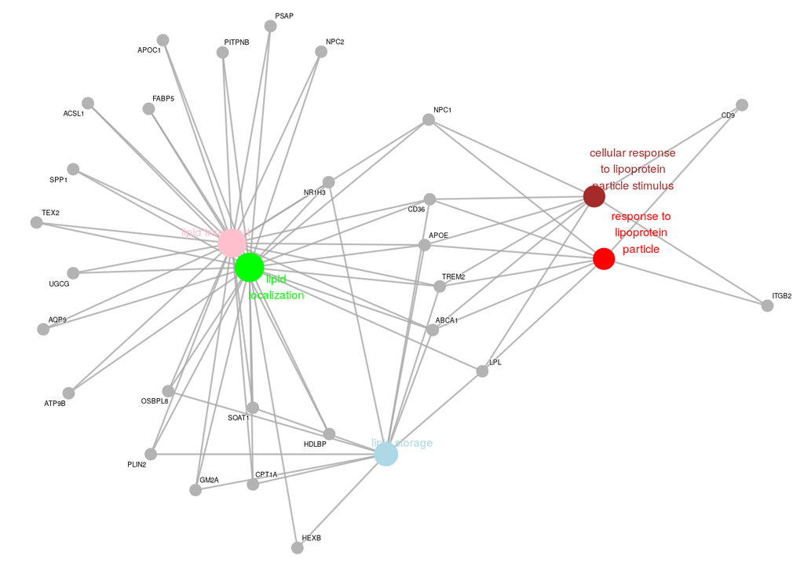

```r
plot(p)
```

```r
rm(p,layout,i,label_color, GO_res)
```

# 8 figure 3H

## 8.1 image 20230306SPP1_CD206_BODIPY_DAPI_63x9

```r
intensity = read.csv(paste0(working.dir, "/IPF_manuscript/meta_data/imaging_results/20230306SPP1_CD206_BODIPY_DAPI_63x9_FijiResults.csv"),header = TRUE)
num_points = 6

intensity$point = rep(paste0("point",c(1:num_points)),4)
intensity$marker = c(rep("SPP1",num_points),rep("CD206",num_points),rep("Bodipy",num_points),rep("DAPI",num_points))

intensity$image = "20230306SPP1_CD206_BODIPY_DAPI_63x9"

intensity_tmp = tidyr::pivot_wider(intensity[,c("point","marker","Mean")],names_from = marker,values_from = Mean)
```

### 8.1.1 CD206 vs SPP1

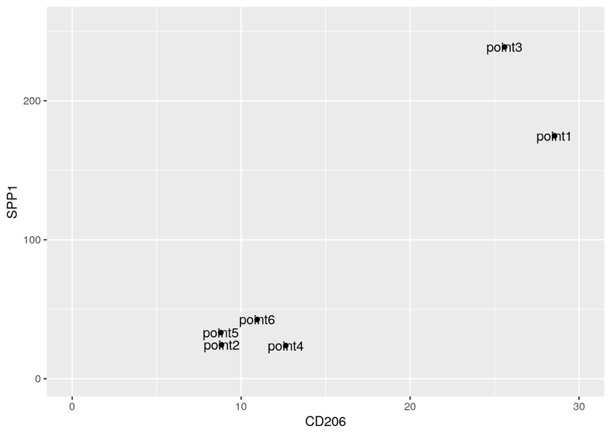

```r
ggplot(intensity_tmp,aes(CD206,SPP1,label=point))+
  geom_point()+
  geom_text()+
  xlim(c(0,30))+
  ylim(c(0,255))
```

### 8.1.2 Bodipy vs SPP1

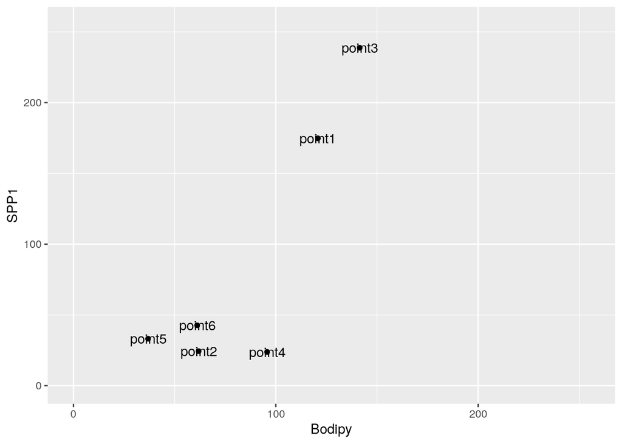

```r
ggplot(intensity_tmp,aes(Bodipy,SPP1,label=point))+
  geom_point()+
  geom_text()+
  xlim(c(0,255))+
  ylim(c(0,255))
```

### 8.1.3 remove non macrophages

```r
intensity$note = ifelse(intensity$point %in% c("point2","point5"),"nonMac","Mac")
```

### 8.1.4 rename file

```r
intensity9=intensity

rm(intensity,intensity_tmp)
```

## 8.2 image 20230306SPP1_CD206_BODIPY_DAPI_63x12

```r
intensity = read.csv(paste0(working.dir, "/IPF_manuscript/meta_data/imaging_results/20230306SPP1_CD206_BODIPY_DAPI_63x12_FijiResults.csv"),header = TRUE)
num_points = 5

intensity$point = rep(paste0("point",c(1:num_points)),4)
intensity$marker = c(rep("SPP1",num_points),rep("CD206",num_points),rep("Bodipy",num_points),rep("DAPI",num_points))

intensity$image = "20230306SPP1_CD206_BODIPY_DAPI_63x12"

intensity_tmp = tidyr::pivot_wider(intensity[,c("point","marker","Mean")],names_from = marker,values_from = Mean)
```

### 8.2.1 CD206 vs SPP1

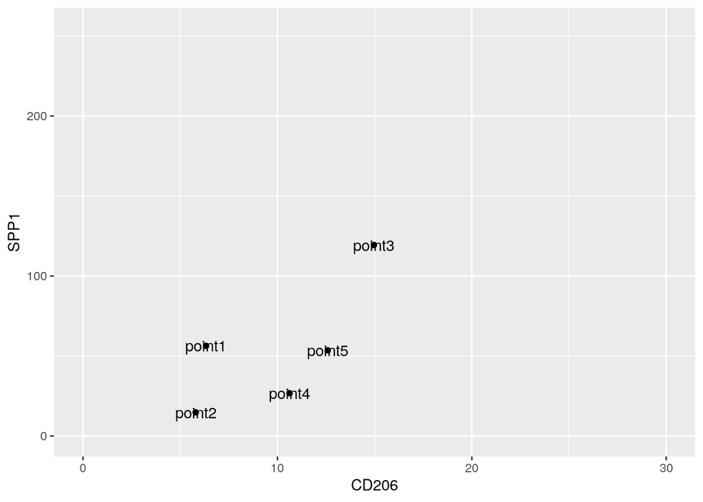

```r
ggplot(intensity_tmp,aes(CD206,SPP1,label=point))+
  geom_point()+
  geom_text()+
  xlim(c(0,30))+
  ylim(c(0,255))
```

### 8.2.2 Bodipy vs SPP1

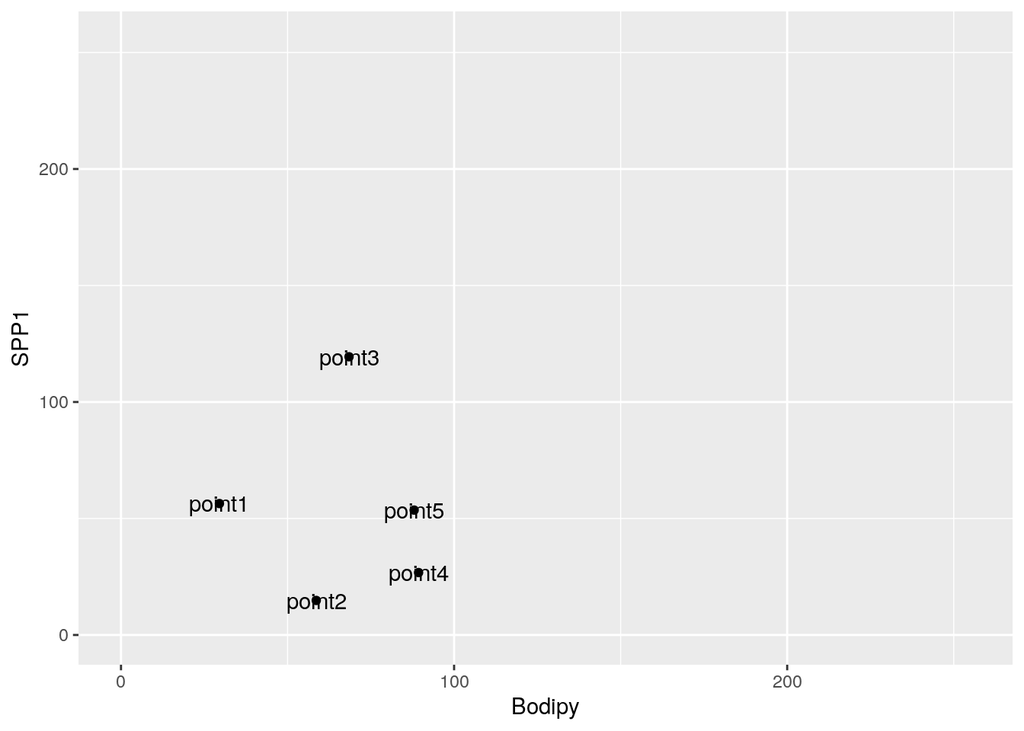

```r
ggplot(intensity_tmp,aes(Bodipy,SPP1,label=point))+
  geom_point()+
  geom_text()+
  xlim(c(0,255))+
  ylim(c(0,255))
```

### 8.2.3 remove non macrophages

```r
intensity$note = ifelse(intensity$point %in% c("point4"),"nonMac","Mac")
```

### 8.2.4 rename file

```r
intensity12=intensity

rm(intensity,intensity_tmp)
```

## 8.3 image 20230306SPP1_CD206_BODIPY_DAPI_63x13

```r
intensity = read.csv(paste0(working.dir, "/IPF_manuscript/meta_data/imaging_results/20230306SPP1_CD206_BODIPY_DAPI_63x13_FijiResults.csv"),header = TRUE)
num_points = 6

intensity$point = rep(paste0("point",c(1:num_points)),4)
intensity$marker = c(rep("SPP1",num_points),rep("CD206",num_points),rep("Bodipy",num_points),rep("DAPI",num_points))

intensity$image = "20230306SPP1_CD206_BODIPY_DAPI_63x13"

intensity_tmp = tidyr::pivot_wider(intensity[,c("point","marker","Mean")],names_from = marker,values_from = Mean)
```

### 8.3.1 CD206 vs SPP1

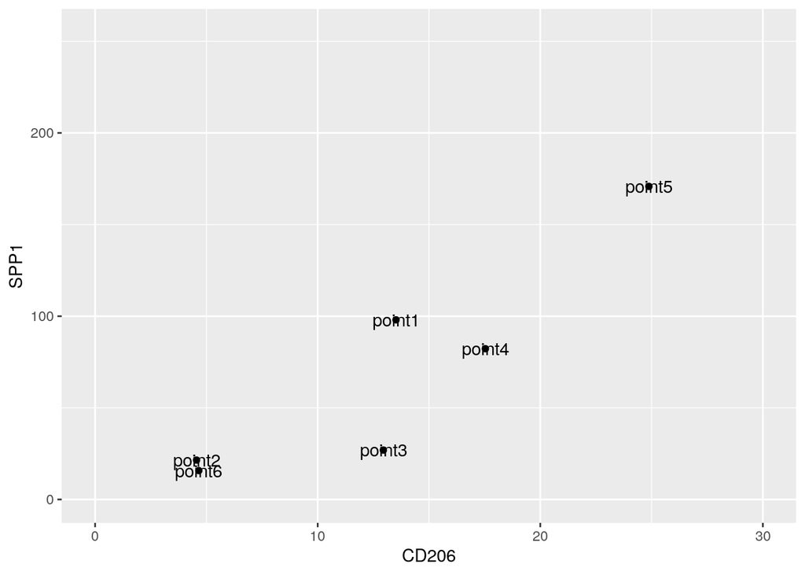

```r
ggplot(intensity_tmp,aes(CD206,SPP1,label=point))+
  geom_point()+
  geom_text()+
  xlim(c(0,30))+
  ylim(c(0,255))
```

### 8.3.2 Bodipy vs SPP1

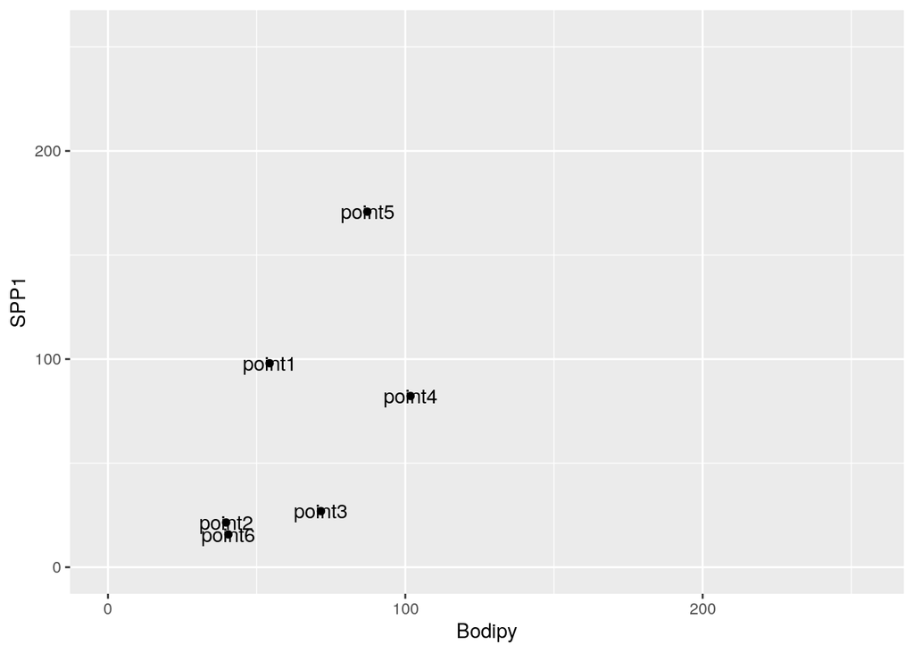

```r
ggplot(intensity_tmp,aes(Bodipy,SPP1,label=point))+
  geom_point()+
  geom_text()+
  xlim(c(0,255))+
  ylim(c(0,255))
```

### 8.3.3 remove non macrophages

based on shape

```r
intensity$note = ifelse(intensity$point %in% c(),"nonMac","Mac")
```

### 8.3.4 rename file

```r
intensity13=intensity

rm(intensity,intensity_tmp)
```

## 8.4 image 20230306SPP1_CD206_BODIPY_DAPI_63x14

```r
intensity = read.csv(paste0(working.dir, "/IPF_manuscript/meta_data/imaging_results/20230306SPP1_CD206_BODIPY_DAPI_63x14_FijiResults.csv"),header = TRUE)
num_points = 5

intensity$point = rep(paste0("point",c(1:num_points)),4)
intensity$marker = c(rep("SPP1",num_points),rep("CD206",num_points),rep("Bodipy",num_points),rep("DAPI",num_points))

intensity$image = "20230306SPP1_CD206_BODIPY_DAPI_63x14"

intensity_tmp = tidyr::pivot_wider(intensity[,c("point","marker","Mean")],names_from = marker,values_from = Mean)
```

### 8.4.1 CD206 vs SPP1

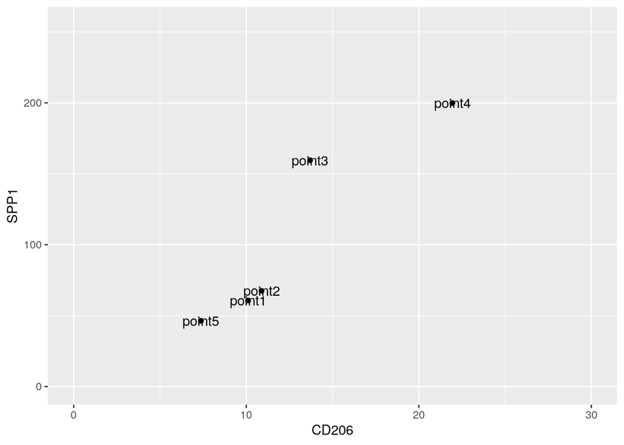

```r
ggplot(intensity_tmp,aes(CD206,SPP1,label=point))+
  geom_point()+
  geom_text()+
  xlim(c(0,30))+
  ylim(c(0,255))
```

### 8.4.2 Bodipy vs SPP1

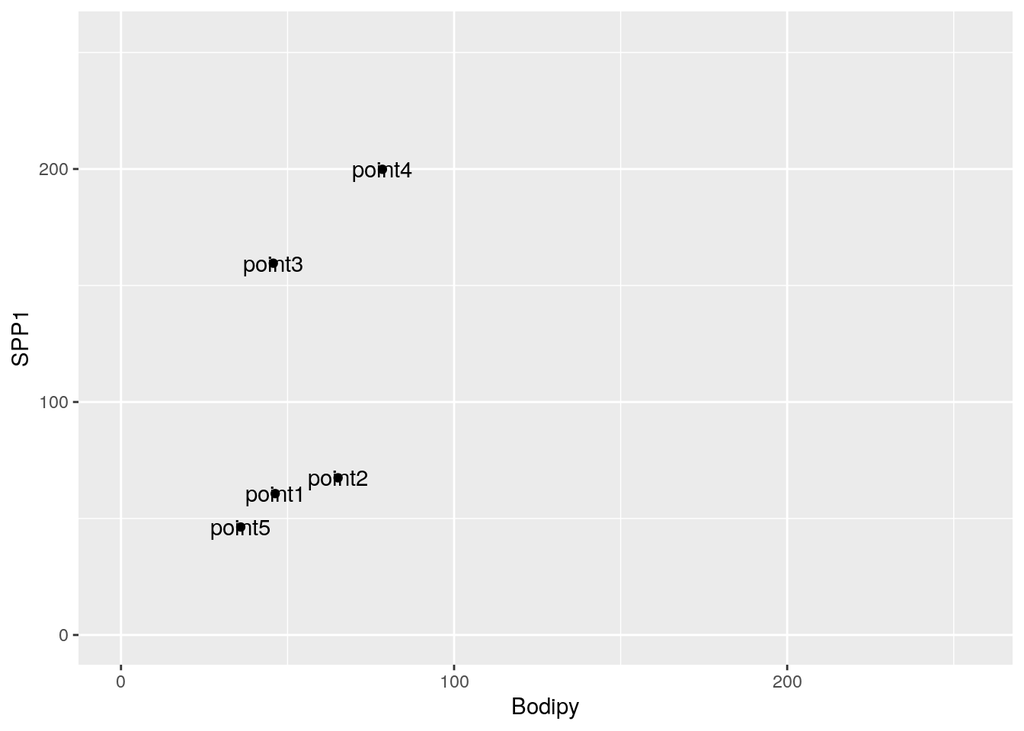

```r
ggplot(intensity_tmp,aes(Bodipy,SPP1,label=point))+
  geom_point()+
  geom_text()+
  xlim(c(0,255))+
  ylim(c(0,255))
```

### 8.4.3 remove non macrophages

based on shape

```r
intensity$note = ifelse(intensity$point %in% c("point3"),"nonMac","Mac")
```

### 8.4.4 rename file

```r
intensity14=intensity

rm(intensity,intensity_tmp)
```

## 8.5 combine all together

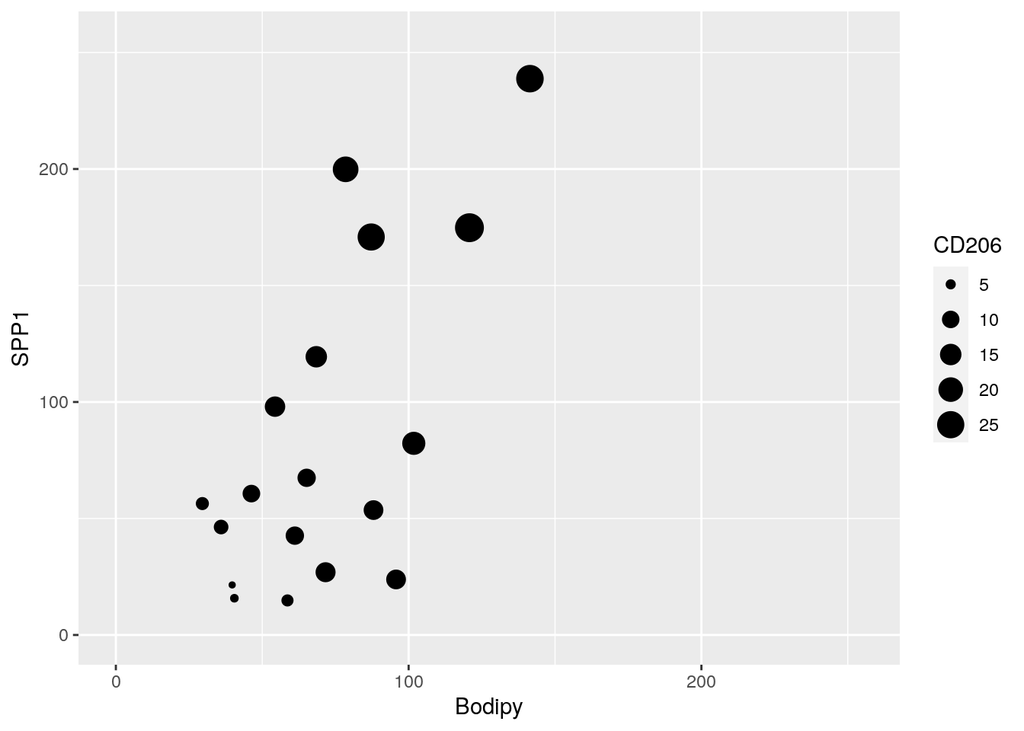

```r
com_int = rbind(intensity9,intensity12,intensity13,intensity14)
com_int$point = paste0(com_int$image,com_int$point)
com_int1 = subset(com_int,note == "Mac")

com_int_tmp = tidyr::pivot_wider(com_int1[,c("point","marker","Mean")],names_from = marker,values_from = Mean)

com_int_tmp$SPP1_group = ifelse(com_int_tmp$SPP1>150,"SPP1_high","SPP1_low")

ggplot(com_int_tmp,aes(Bodipy,SPP1,label=point,size=CD206))+
  geom_point()+
  # geom_text()+
  xlim(c(0,255))+
  ylim(c(0,255))
```

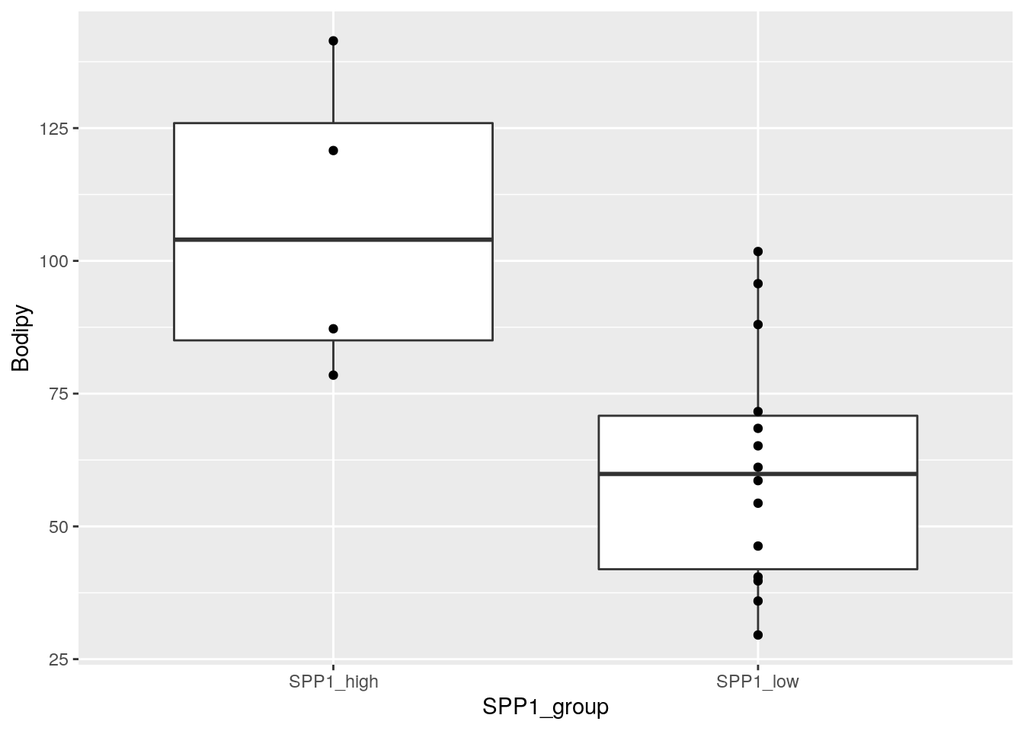

```r
ggplot(com_int_tmp,aes(SPP1_group,Bodipy))+
  geom_boxplot()+
  geom_point()
```

# 9 plot figure 3H

```r
pdf(file = paste0(ms_dir,"/fig3h.SPP1_bodipy_imaging_",ms_date,".pdf"),paper = "a4",width = 1.8,height = 2.2)

my_comparisons <- list( c("SPP1_low","SPP1_high"))
my_color = c("SPP1_low"="#344e41","SPP1_high"="#ffafcc")

# remotes::install_github("clauswilke/ggtext")
library(ggtext)
com_int_tmp$SPP1_group = factor(com_int_tmp$SPP1_group,levels = c("SPP1_low","SPP1_high"))

p = ggplot(com_int_tmp,aes(SPP1_group,Bodipy,fill=SPP1_group,size=CD206))+
  geom_boxplot(outlier.colour="red", outlier.shape=8,outlier.size=4)+
  geom_dotplot(binaxis='y', stackdir='center', dotsize=0.7,fill="white")+
  scale_fill_manual(values = my_color)+
  ggpubr::stat_compare_means(aes(label = ..p.signif..),comparisons = my_comparisons,method = "t.test",hide.ns = TRUE,bracket.size = 0.5,vjust = 0.6)+
  ylim(c(0,150))+
  # geom_jitter(shape=16)+
  theme_classic()+
   # labs(title = paste0(i,":Wilcox test p =", res$p.value))+
   # labs(title = i)+
  ylab(label = paste0("Bodipy mean intensity"))+
  xlab("")+
  scale_x_discrete(labels=c(expression(SPP1^"-" * M*phi),expression(SPP1^"+" * M*phi)))+
   theme(axis.text.x = element_text(size = 8),
         axis.text.y = element_text(size = 8),
         axis.title.y = element_text(size = 8),
         legend.position = "none")
plot(p)
dev.off()
```

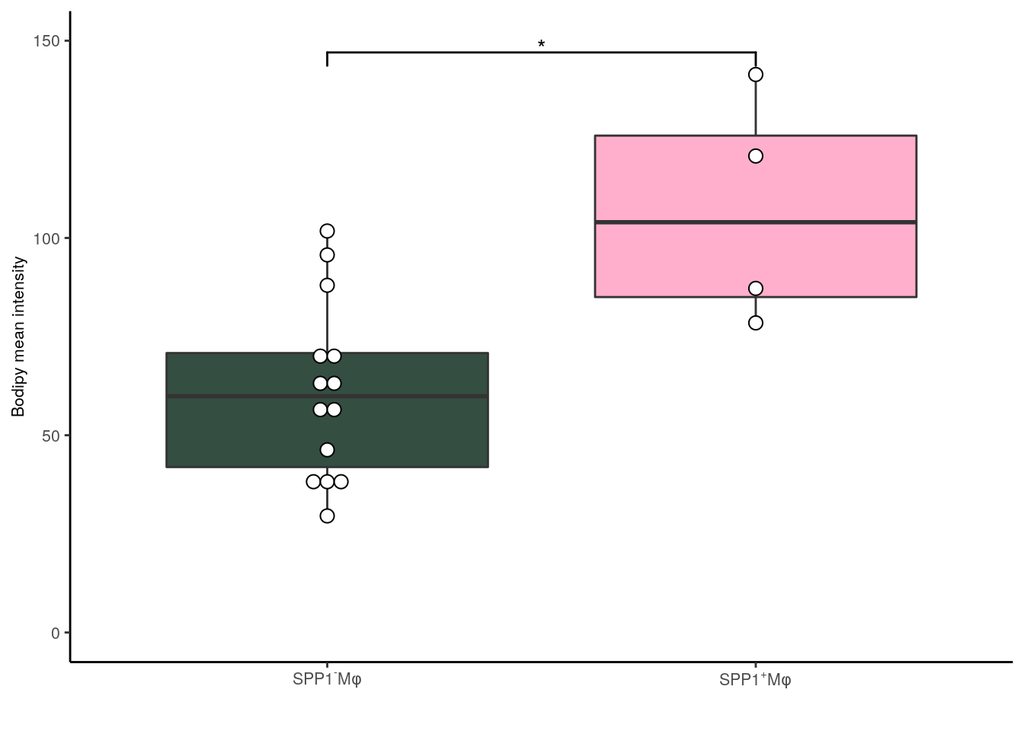

```r
p
```

```r
rm(intensity9,intensity12,intensity13,intensity14,com_int,com_int1,my_comparisons,my_color,num_points)
```

# 10 plot figure S4C

```r
pdf(file = paste0(ms_dir,"/figs4c.SPP1_bodipy_imaging_",ms_date,".pdf"),paper = "a4",width = 3.8,height = 2.5)

my_color = c("SPP1_low"="#344e41","SPP1_high"="#ffafcc")

library(ggtext)
com_int_tmp$SPP1_group = factor(com_int_tmp$SPP1_group,levels = c("SPP1_low","SPP1_high"))

p = ggplot(com_int_tmp,aes(x=Bodipy,y=SPP1,color=SPP1_group,size=CD206))+
  geom_point()+
  scale_color_manual(name = "Group",values = my_color,labels=c("SPP1_low"=expression(SPP1^"-" * M*phi),"SPP1_high"=expression(SPP1^"+" * M*phi)))+
  scale_size(breaks = c(10,20,30))+
  xlim(c(0,150))+
  theme_classic()+
  xlab(label = paste0("Bodipy mean intensity"))+
  ylab(label = paste0("SPP1 mean intensity"))+
  # scale_x_discrete(labels=c(expression(SPP1^"-" * M*phi),expression(SPP1^"+" * M*phi)))+
   theme(axis.text = element_text(size = 8),
         # axis.text = element_text(size = 8),
         axis.title = element_text(size = 8),
         legend.title = element_text(size=8),
         legend.text = element_text(size=8),
         legend.position = "left")+
  guides(size = guide_legend(order = 1,title = "CD206 mean intensity"))
         # color = guide_colorbar(order = 2,title = "Group"))

plot(p)
dev.off()
```

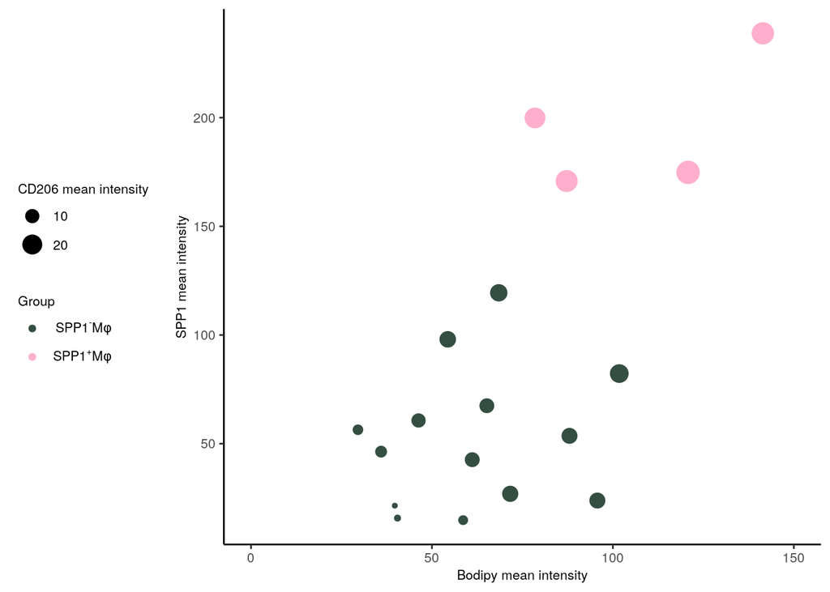

```r
p
```

```r
rm(p)
```

# 11 figure S4A

```r
pdf(file = paste0(ms_dir,"/figs4a.TREM2+_prediction_score_",ms_date,".pdf"),paper = "a4",width = 3,height = 2.5)

##use same colors for cluster 7, 13, 20
mac_color = c("0" = "#344e41",
                             "4_0" = "#FF1493",
                         "4_1" = "#48cae4",
                         "4_2" = "#ffafcc",
                             "6" = "#BDE4C8",
                             "7" = "#6a994e",
                             "8" = "#73BCEB",
                             "10" = "#00b4d8",
                             "11" = "#467599",
                             "13" = "#6a994e",
                             "20" = "#6a994e")


mac_label = c("0" = expression(Alveolar*"-"*M*phi1*(0)),
                             "4_0" = "Monocyte(4_0)",
                             "4_1" = expression(RNASE1^"+"*M*phi1*(4*"_"*1)),
                             "4_2" = expression(SPP1^"+"*M*phi1*(4*"_"*2)),
                             "6" = expression(S100A11^"+"*M*phi1*(6)),
                             "7" = expression(MKI67^"+"*M*phi1*(7*","*13*","*20)),
                             "8" = expression(CXCL10^"+"*M*phi1*(8)),
                             "10" = expression(TNFAIP6^"+"*M*phi1*(10)),
                             "11" = expression(NEAT1^"+"*M*phi1*(11)),
                             "13" = expression(MKI67^"+"*M*phi1*(7*","*13*","*20)),
                             "20" = expression(MKI67^"+"*M*phi1*(7*","*13*","*20)))

p = VlnPlot(ipf_seu_mac,features = c("prediction.score.TREM2.Macrophage..3"),pt.size = 0,group.by = "subcluster1")+
  xlab("")+
  ylab("Prediction score")+
  labs(title = expression(TREM2^"+"*M*phi1*"("*Mulder*" "*et*" "*al*")"))+
  scale_fill_manual(values = mac_color)+
  scale_x_discrete(labels = mac_label)+
  coord_flip()+
  theme(axis.text.x = element_text(angle = 0, vjust = 0, hjust=0.5,size = 8),
        axis.text.y = element_text(size = 8),
        axis.title = element_text(size = 8),
        plot.title = element_text(size = 8,face = "plain"),
        plot.title.position = "plot",
        legend.position = "none")+
  scale_fill_manual(name = "Cluster",
                     labels = mac_label[1:9],
                     values = mac_color[1:9])
plot(p)

dev.off()
```

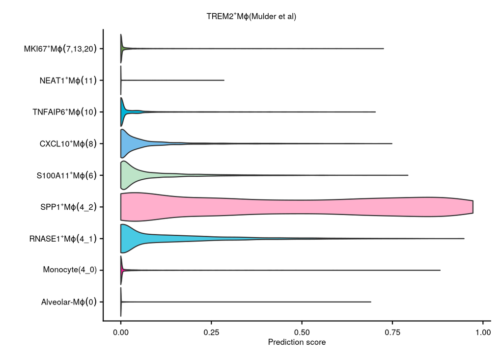

```r
p
```

```r
rm(mac_color,mac_label,p)
```

# 12 figure S4b

```r
mac_label = c("0" = expression(Alveolar*"-"*M*phi1*(0)),
                             "4_0" = "Monocyte(4_0)",
                             "4_1" = expression(RNASE1^"+"*M*phi1*(4*"_"*1)),
                             "4_2" = expression(SPP1^"+"*M*phi1*(4*"_"*2)),
                             "6" = expression(S100A11^"+"*M*phi1*(6)),
                             "7" = expression(MKI67^"+"*M*phi1*(7*","*13*","*20)),
                             "8" = expression(CXCL10^"+"*M*phi1*(8)),
                             "10" = expression(TNFAIP6^"+"*M*phi1*(10)),
                             "11" = expression(NEAT1^"+"*M*phi1*(11)),
                             "13" = expression(MKI67^"+"*M*phi1*(7*","*13*","*20)),
                             "20" = expression(MKI67^"+"*M*phi1*(7*","*13*","*20)))

gsea_data = read.csv(file = paste0(working.dir,"/IPF_manuscript/manuscriptV3/meta_data/GSEA_allmac.csv"))
test = gsea_data[!gsea_data$cluster %in% c(7,13,20),]
test = subset(test,p.adjust<0.00001)
test = gsea_data[rownames(gsea_data) %in% rownames(test),]
# %>% group_by(cluster) %>% top_n(n = 5, wt = Count)
# test = subset(test,p.adjust < 0.0001)

test$cluster = factor(test$cluster,levels = c("4_0","4_1","4_2",6,8,10,11))
test = test[order(test$cluster),]
test$Description = factor(test$Description,levels = unique(test$Description))

pdf(file = paste0(ms_dir,"/figs4b.allMac.GSEA_",ms_date,".pdf"),paper = "a4",width = 7,height = 4)

p = ggplot(test, aes(x = cluster, y = Description, color = p.adjust)) +
      geom_point(aes(size = Count)) +
      scale_x_discrete(labels = mac_label)+
      scale_size(breaks = c(5,10,15))+
      # scale_colour_gradientn(colours=c('red',
      #                                  'orange',
      #                                  'darkblue'),
      #                        # limits=c(0,0.05),
      #                        values   = c(0,0.00001,0.001)
      #                        # breaks   = c(0,0.001,0.05),
      #                        # labels = format(c(0,0.001,0.05))
      #                        ) +
      ylab(NULL) +
      xlab(NULL) +
      # ggtitle(paste(strwrap(unique(x$Enrichment), width=title.width), collapse = "\n"))+
      theme_classic() +
      scale_y_discrete(position = "left") +
      coord_flip()+
      theme(text = element_text(size=8),
            plot.title = element_text(size=8),
            axis.text = element_text(size=6),
            axis.text.x = element_text(angle = 90, vjust = 0.5, hjust=1),
            legend.position = "top") +
            # legend.box.margin = margin(-250,0,0,0))+
      guides(size = guide_legend(order = 1,title = "Count"),
         color = guide_colorbar(order = 2,title = "p.adjust",barheight = 0.5,barwidth=8))
plot(p)
dev.off()
```

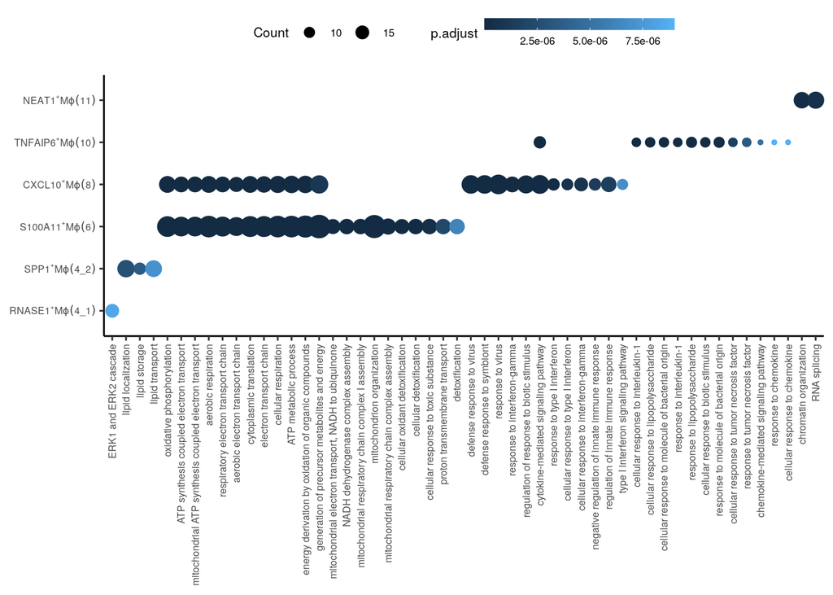

```r
p
```

```r
rm(test,gsea_data,mac_label,p)
```

# 13 figure S4D

## 13.1 load seurat object

```r
ipf_seu_mac = readRDS(file=paste0(working.dir,"/IPF_manuscript/data/ILD_combined_sct_rpca20230720_mac.rds"))


Idents(ipf_seu_mac) = "subcluster"

##use same colors for cluster 7, 13, 20
mac_color = c("0" = "#344e41",
                             "4_0" = "#FF1493",
                         "4_1" = "#48cae4",
                         "4_2" = "#ffafcc",
                             "6" = "#BDE4C8",
                             "7" = "#6a994e",
                             "8" = "#73BCEB",
                             "10" = "#00b4d8",
                             "11" = "#467599",
                             "13" = "#6a994e",
                             "20" = "#6a994e")


mac_label = c("0" = expression(Alveolar*"-"*M*phi1*(0)),
                             "4_0" = "Monocyte(4_0)",
                             "4_1" = expression(RNASE1^"+"*M*phi1*(4*"_"*1)),
                             "4_2" = expression(SPP1^"+"*M*phi1*(4*"_"*2)),
                             "6" = expression(S100A11^"+"*M*phi1*(6)),
                             "7" = expression(MKI67^"+"*M*phi1*(7*","*13*","*20)),
                             "8" = expression(CXCL10^"+"*M*phi1*(8)),
                             "10" = expression(TNFAIP6^"+"*M*phi1*(10)),
                             "11" = expression(NEAT1^"+"*M*phi1*(11)),
                             "13" = expression(MKI67^"+"*M*phi1*(7*","*13*","*20)),
                             "20" = expression(MKI67^"+"*M*phi1*(7*","*13*","*20)))
```

## 13.2 plot figure

```r
ipf_seu_mac$subcluster1 = ifelse(ipf_seu_mac$subcluster %in% c(13,20),"7",as.character(ipf_seu_mac$subcluster))
ipf_seu_mac$subcluster1 = factor(ipf_seu_mac$subcluster1,levels = c(0,"4_0","4_1","4_2",6,8,10,11,7))

Idents(ipf_seu_mac) = "subcluster1"
ipf_seu_mac$IPFgroup = factor(ipf_seu_mac$IPFgroup,levels = c("Control","Early-IPF","Advanced-IPF"))
DefaultAssay(ipf_seu_mac) = "RNA"

plot_label = c("0" = "0",
               "4_0" = "4_0",
               "4_1" = "4_1",
               "4_2" = "4_2",
               "6" = "6",
               "8" = "8",
               "10" = "10",
               "11" = "11",
               "7" = "7,13,20"
               )

plot_color =  c(
                "Control" = "grey",
                "Early-IPF" = "#076B94",
                "Advanced-IPF" = "#E0B32D"
                )

p1 = VlnPlot(ipf_seu_mac,features = c("LPL"),split.by = "IPFgroup",pt.size = 0,group.by = "subcluster1",cols = plot_color)+
  # coord_flip()+
  scale_x_discrete(labels = plot_label)+
  ylab(label = "Expression level")+
  theme(axis.text.y = element_text(size=8),
        axis.text.x = element_text(size=8,angle = 90),
        axis.title.x = element_blank(),
        axis.title.y = element_text(size=8),
        plot.title = element_text(size=8,face = "plain",margin = margin(0,0,-2,0)),
        plot.margin = unit(c(-10,0,-10,0),units = "cm"),
    legend.position = "none")
```

```
## The default behaviour of split.by has changed.
## Separate violin plots are now plotted side-by-side.
## To restore the old behaviour of a single split violin,
## set split.plot = TRUE.
##
## This message will be shown once per session.
```

```r
p2 = VlnPlot(ipf_seu_mac,features = c("LIPA"),split.by = "IPFgroup",pt.size = 0,cols = plot_color)+
  scale_x_discrete(labels = plot_label)+
  ylab(label = "Expression level")+
  theme(axis.text.y = element_text(size=8),
        axis.text.x = element_text(size=8,angle = 90),
        axis.title = element_blank(),
        # axis.title.y = element_text(size=8),
        plot.title = element_text(size=8,face = "plain",margin = margin(0,0,-2,0)),
        plot.margin = unit(c(-10,0,-10,0),units = "cm"),
    legend.position = "none")

p3 = VlnPlot(ipf_seu_mac,features = c("CCL18"),split.by = "IPFgroup",pt.size = 0,cols = plot_color)+
  scale_x_discrete(labels = plot_label)+
  labs(title = "CCL18 (mRNA)")+
  ylab(label = "Expression level")+
  theme(axis.text.y = element_text(size=8),
        axis.text.x = element_text(size=8,angle = 90),
        axis.title.x = element_blank(),
        axis.title.y = element_text(size=8),
        plot.title = element_text(size=8,face = "plain",margin = margin(0,0,-2,0)),
        plot.margin = unit(c(-10,0,-10,0),units = "cm"),
    legend.position = "none")

p4 = ggplot()+
  geom_point(aes(1,1,colour = "Control"))+
  geom_point(aes(2,2,colour = "Early-IPF"))+
  geom_point(aes(3,3,colour = "Advanced-IPF"))+
  scale_color_manual(values = plot_color)+
  theme(legend.text = element_text(size = 8,colour = "black"),
        legend.title = element_text(size = 8,colour = "black"),
        legend.background = element_blank(),
        legend.key = element_blank(),
        plot.margin = margin(0,0,0,-10,"cm"))+
  guides(color=guide_legend(title = "Group"))

p4 = cowplot::get_legend(p4)

pdf(file = paste0(ms_dir,"/figs4d_LIPA_LPL_vlnplot",ms_date,".pdf"),paper = "a4",width = 7,height = 2)
ggpubr::ggarrange(p1,p2,p4,nrow = 1,ncol = 3,widths = c(3.1,3.1,0.8))
dev.off()
```

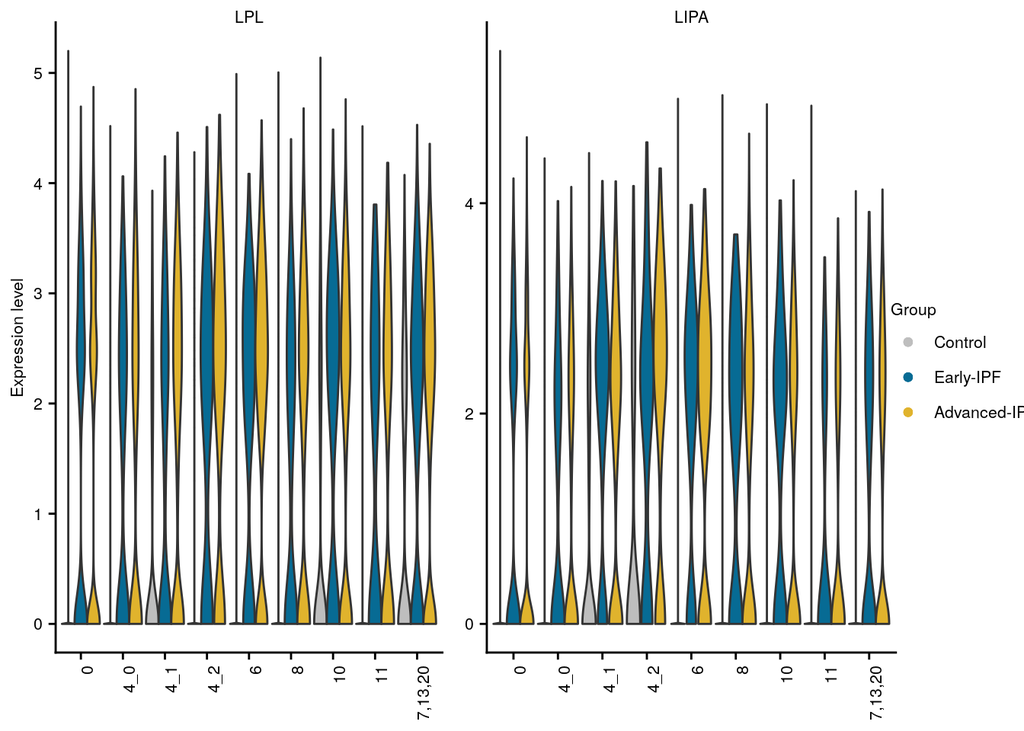

```r
ggpubr::ggarrange(p1,p2,p4,nrow = 1,ncol = 3,widths = c(3.1,3.1,0.8))
```

```r
##pdf(file = paste0(ms_dir,"/fig3b_CCL18_vlnplot",ms_date,".pdf"),paper = "a4",width = 5,height = 2)
# ggpubr::ggarrange(p3,p4,nrow = 1,ncol = 2,widths = c(4,1))
##dev.off()

rm(p1,p2,p3,p4,plot_label,plot_color)
```

R version 4.1.3 (2022-03-10) Platform: x86_64-pc-linux-gnu (64-bit) Running under: Ubuntu 20.04.4 LTS

Matrix products: default BLAS/LAPACK: /usr/lib/x86_64-linux-gnu/openblas-pthread/libopenblasp-r0.3.8.so

locale: [1] C

attached base packages: [1] grid splines stats4 stats graphics grDevices utils  
[8] datasets methods base

other attached packages: [1] ggtext_0.1.1 gam_1.22-2 foreach_1.5.2  
[4] ComplexHeatmap_2.10.0 DOSE_3.20.1 org.Mm.eg.db_3.14.0  
[7] org.Hs.eg.db_3.14.0 AnnotationDbi_1.56.2 IRanges_2.28.0  
[10] S4Vectors_0.32.4 Biobase_2.54.0 BiocGenerics_0.40.0  
[13] clusterProfiler_4.2.2 biomaRt_2.50.3 DescTools_0.99.50  
[16] data.table_1.14.2 future_1.24.0 plotly_4.10.0  
[19] VGAM_1.1-6 Matrix.utils_0.9.8 Matrix_1.4-0  
[22] tidyr_1.2.0 dplyr_1.0.8 reshape2_1.4.4  
[25] umap_0.2.8.0 stringr_1.4.0 SeuratObject_4.0.4  
[28] Seurat_4.1.0 useful_1.2.6 ggplot2_3.3.5  
[31] cowplot_1.1.1 readr_2.1.2